# Reproducible Research Week 2 Project

## Loading and preprocessing the data

Loading the activity.csv data into R in the correct format and loading any libraries needed to run the analysis below

```r
library(chron)
library(plyr)
library(lattice)

activitydata <- read.csv("activity.csv", header = TRUE, na.strings = "NA", stringsAsFactors = FALSE) # import data
activitydata$date <- as.Date(activitydata$date, format = "%Y-%m-%d") # convert date column to correct format
activitydata$day <- weekdays(activitydata$date) # pull out the days of the week
weekendactivity <- activitydata[grepl("Saturday|Sunday", activitydata$day),] # subset a weekend dataframe
weekendactivity$wkday <- "Weekend" # tag the weekend dataframe
weekdayactivity <- activitydata[!grepl("Saturday|Sunday", activitydata$day),] # subset the weekday dataframe
weekdayactivity$wkday <- "Weekday" # tag the weekday dataframe
taggedactivitydata <- rbind(weekdayactivity,weekendactivity) # recombine the data
taggedactivitydata <- taggedactivitydata[order(taggedactivitydata$date),] # return to date order
```

## Investigating the mean number of steps taken in a day

Calculating the total number of steps taken per day, exploring this data using a histogram and calculating the mean and median total number per day.

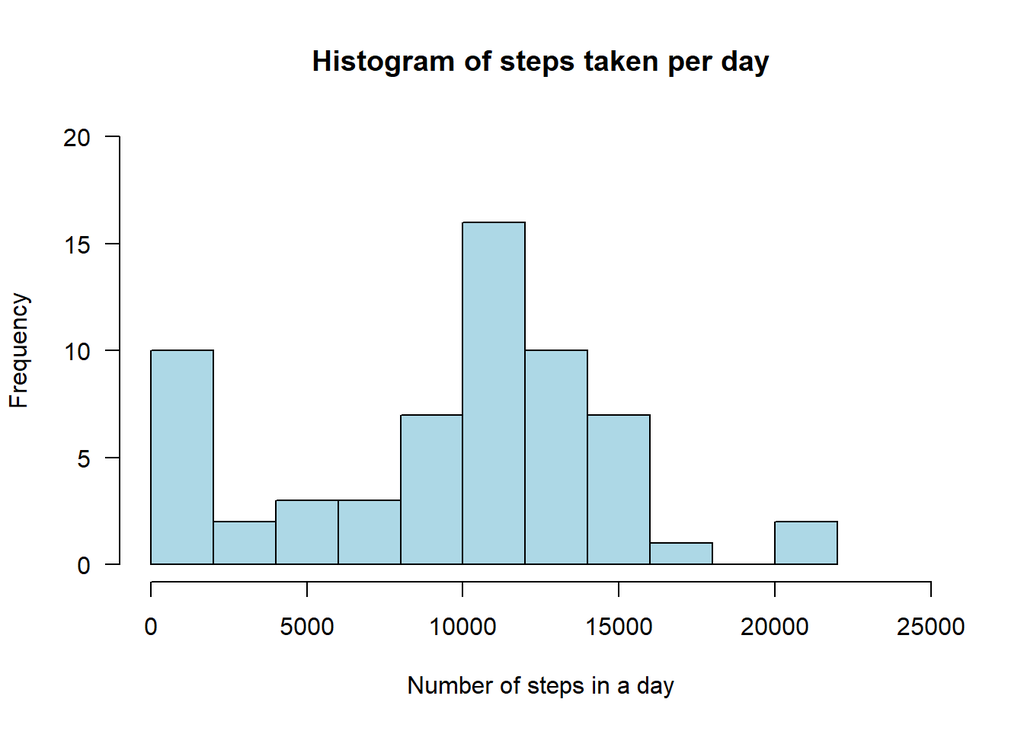

```r
stepsbydate <- with(taggedactivitydata, tapply(steps, date, sum, na.rm=TRUE)) # Calculate total steps per day
hist(stepsbydate, main = "Histogram of steps taken per day", xlab = "Number of steps in a day", col = "lightblue", las=1, breaks = 10, ylim = c(0,20), xlim = c(0,25000)) # Plot histogram of daily steps
```

```r
meansteps <- mean(stepsbydate) # calculate mean daily steps
mediansteps <- median(stepsbydate) # calculate median daily steps
```

The mean number of steps per day is 9354.2295082 and the median is 10395.

## Investigating the average daily activity pattern

Calculate the average number of steps taken per 5 minute interval. Investigate in a time series plot. Identify the interval with the most steps on average per day.

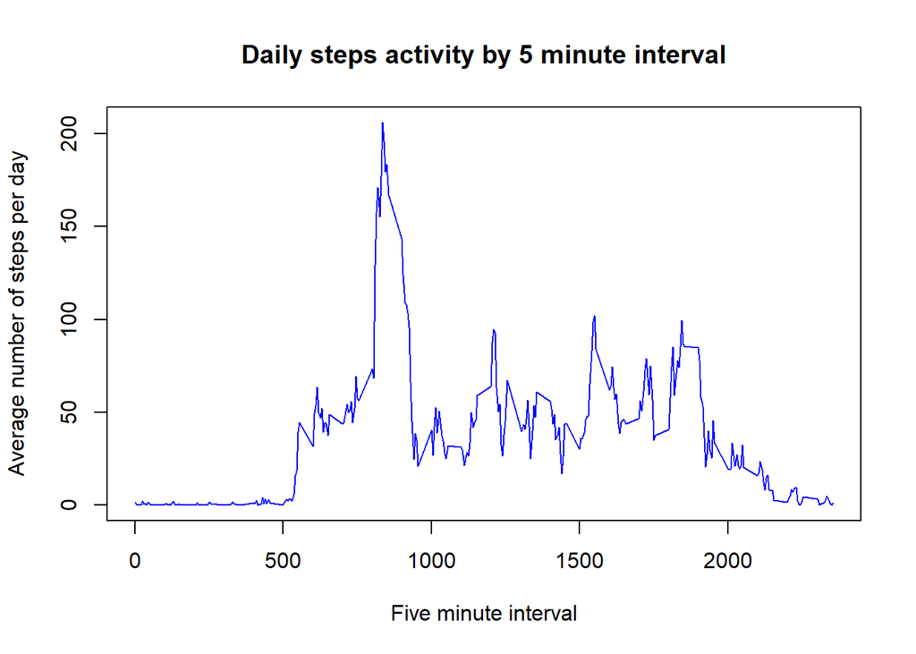

```r
dailyactivity <- with(taggedactivitydata, tapply(steps, interval, mean, na.rm=TRUE)) # Calculate mean steps per interval of the day
plot(x = taggedactivitydata$interval[1:288], y= dailyactivity, type = "l", xlab = "Five minute interval", ylab= "Average number of steps per day", main = "Daily steps activity by 5 minute interval", col = "blue") # Plot a line chart of the steps per interval on an average day
```

```r
mostactiveinterval <- taggedactivitydata$interval[which.max(dailyactivity)] # identify the most active interval
```

Most activity is seen on average during the time interval 835.

## Imputing missing values and reassessing the data

```r
NumNA <- count(is.na(taggedactivitydata$steps)) # calculate the number of NAs in steps data
print(NumNA) # print the answer
```

```
##       x  freq
## 1 FALSE 15264
## 2  TRUE  2304
```

The number of missing steps values is equal to the number of TRUE in the table above.

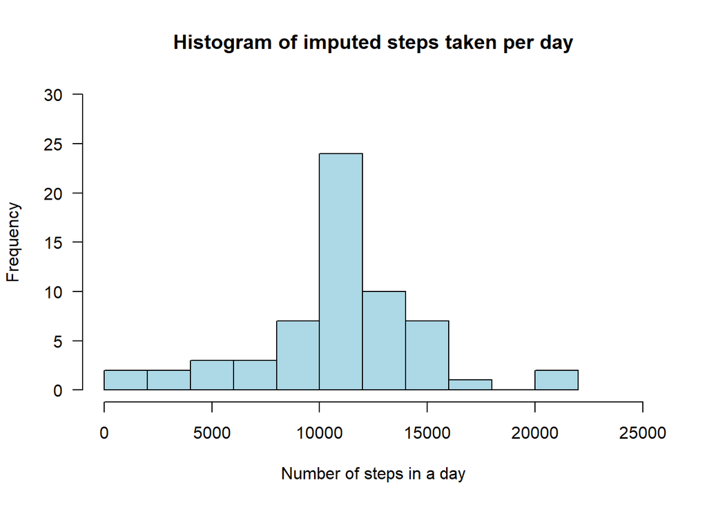

```r
## impute the missing values using the average value for that interval
dailyactivitylong <- rep.int(dailyactivity, 61) # extend daily activity vector to nrows of dataframe
taggedactivitydata$dailyactivity <- dailyactivitylong # append daily activity vector

for (i in 1:nrow(taggedactivitydata)){ # make new column of either average interval value (if NA) or existing steps value if not missing
    if(is.na(taggedactivitydata$steps[i])){
        taggedactivitydata$impmean[i] <- taggedactivitydata$dailyactivity[i]
    }else{
        taggedactivitydata$impmean[i] <- taggedactivitydata$steps[i]
    }
}

impstepsbydate <- with(taggedactivitydata, tapply(impmean, date, sum, na.rm=TRUE)) # re-calculate steps per day
 hist(impstepsbydate, main = "Histogram of imputed steps taken per day", xlab = "Number of steps in a day", col = "lightblue", las=1, breaks = 10, ylim = c(0,30), xlim = c(0,25000)) # plot as histogram
```

```r
 meanimpsteps <- mean(impstepsbydate) # calculate mean
 medianimpsteps <- median(impstepsbydate) # calculate median
```

## Are there differences in activity levels between weekdays and weekends?

The README requests the use of the imputed data on a new factor that gives whether the day in question is a weekday or a weekend day.

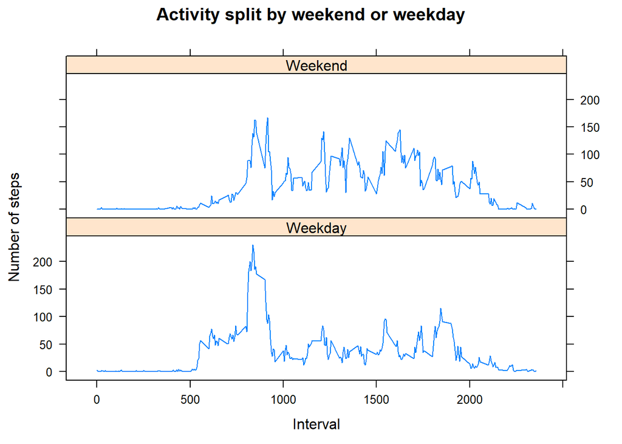

```r
taggedactivitydata$wkday <- as.factor(taggedactivitydata$wkday) # make wkday column a factor

summarydata <- aggregate(impmean ~ interval + wkday, taggedactivitydata, mean) # summarise data by interval and weekday/weekend

xyplot(impmean ~ interval | wkday, summarydata, type = "l", layout = c(1,2), xlab = "Interval", ylab = "Number of steps", main = "Activity split by weekend or weekday") # plot the data on a lattice plot
```